# Итоговый проект

Группа 7

### Идея

**Тип проекта:** рекомендательный

**Данные:** Датасет «Car Price Prediction Challenge» с Kaggle. В нем данные об автомобилях и их рыночных ценах. Все признаки из датасета: ID Price Levy Manufacturer Model Prod. year Category Leather interior Fuel type Engine volume Mileage Cylinders Gear box type Drive wheels Doors Wheel Color Airbags.

Идея проекта: построить модель случайного леса для предсказания рыночной стоимости автомобиля на основе его характеристик, что позволит подбирать автомобили или предсказывать цену для продажи собственного автомобиля пользователя. Проект для автолюбителей, продавцов и покупателей автомобилей, которые хотят узнать рыночную цену автомобиля перед его покупкой/продажей. Итоговая модель будет включать в себя два режима: упрощённый режим помогает новичкам, а расширенный — более опытным пользователям

Для реализации проекта: Изначально была проведена первичная очистка данных: удалены строки с пропущенными значениями и символом “-” в числовых переменных. Далее были преобразованы в числовой тип переменные Levy (налог), Mileage (пробег, предварительно очищенный от символов “km”), Engine.volume (объем двигателя) и Cylinders (количество цилиндров). Также был исключен ID.

Затем были рассчитаны описательные статистики, проведён корреляционный анализ между количественными признаками. Данные были разделены на обучающую (80%) и тестовую (20%) выборки. И была построена предварительная модель случайного леса. Она показала средний уровень точности, и чтобы повысить качество прогноза, мы попытались оптимизировать модель. Сначала, мы увеличили количество деревьев до 400. Улучшенная версия показала повышение точности. Затем, была протестирована модель с 350 деревьями. Она продемонстрировала лучшие результаты по RMSE и R^2 по сравнению с двумя предыдущими моделями. Модели были протестированы с использованием кросс-валидации, что позволило избежать переобучения и убедиться в стабильности моделей. В итоге, мы использовали модель случайного леса с 350 деревьями.

Затем мы разработали интерфейс приложения с разделением на упрощенный/расширенный: упрощенный включал ввод марки автомобиля, года выпуска и модели, а в расширенном добавились прееменные (тип топлива, пробег, объем двигателя, количество цилиндров, тип коробки передач). Также добавили обработку ошибок. Затем после сбора обратной связи от пользователей мы добавили вывод цены как доверительный интервал нормального распределения.

### Распределение ролей

1. Подолин Дмитрий Алексеевич: Создание модели для предсказания стоимости автомобиля; Создание интерфейса
2. Семенова Мария Тимофеевна: Разработка идеи проекта и сценариев для пользователей, ограничений; Создание модели для предсказания стоимости автомобиля
3. Смульская Ульяна Александровна: Разработка идеи проекта и сценариев для пользователей, ограничений; Выбор методов и оценивание работы моделей
4. Татаев Гурам Давидович: Разработка интерфейса; Выбор методов и оценивание работы моделей

### Предобработка

Были загружены нужные библиотеки, а также датасет, который был скачен с [Kaggle](https://www.kaggle.com/datasets/deepcontractor/car-price-prediction-challenge). Из датасета были удалены строки с пропущенными значениями и символом “-” в числовых переменных. Далее были преобразованы в числовой тип переменные Levy (налог), Mileage (пробег, предварительно очищенный от символов “km”), Engine.volume (объем двигателя) и Cylinders (количество цилиндров). Также был исключен ID. Далее датасет использовался для построения моделей. Также посмотрели на описательные статистики датасета и на матрицу корреляций для дальнейшего подбора параметров.

```r
# Загрузим библиотеки
library(corrplot)
library(dplyr)
library(caret)
library(randomForest)
library(ggplot2)

# Загрузка данных
df <- read.csv("car_price_prediction.csv", stringsAsFactors = FALSE)

# Удалим строки с пропущенными значениями и лишние символы
df_clean1 = dplyr::mutate(df,
    Levy = as.numeric(Levy),
    Mileage = as.numeric(gsub(" km", "", gsub(",", "", Mileage))),
    Engine.volume = as.numeric(Engine.volume),
    Cylinders = as.numeric(Cylinders))
df_clean = dplyr::filter(df_clean1, df_clean1$Levy != "-" & df_clean1$Engine.volume != "-")
df_clean = select(df_clean, -ID)

# Описательные статистики
summary(select(df_clean, where(is.numeric)))
```

```
##      Price             Levy           Prod..year   Engine.volume
##  Min.   :     1   Min.   :   87.0   Min.   :1992   Min.   : 0.000
##  1st Qu.:  3293   1st Qu.:  640.0   1st Qu.:2011   1st Qu.: 1.800
##  Median : 12980   Median :  781.0   Median :2013   Median : 2.000
##  Mean   : 16645   Mean   :  909.4   Mean   :2013   Mean   : 2.336
##  3rd Qu.: 22843   3rd Qu.: 1058.0   3rd Qu.:2015   3rd Qu.: 2.500
##  Max.   :872946   Max.   :11714.0   Max.   :2020   Max.   :20.000
##     Mileage            Cylinders         Airbags
##  Min.   :        0   Min.   : 1.000   Min.   : 0.000
##  1st Qu.:    68726   1st Qu.: 4.000   1st Qu.: 4.000
##  Median :   119619   Median : 4.000   Median : 4.000
##  Mean   :   218672   Mean   : 4.519   Mean   : 6.797
##  3rd Qu.:   180659   3rd Qu.: 4.000   3rd Qu.:12.000
##  Max.   :999999999   Max.   :14.000   Max.   :16.000
```

```r
# Матрица корреляций
cor_matrix <- cor(select(df_clean, where(is.numeric)), use = "complete.obs")
print(cor_matrix)
```

```
##                      Price        Levy  Prod..year Engine.volume      Mileage
## Price          1.000000000  0.05879544  0.30035036   0.019003937 -0.009387788
## Levy           0.058795444  1.00000000 -0.21884969   0.652976947  0.012353054
## Prod..year     0.300350364 -0.21884969  1.00000000  -0.103710947 -0.057448555
## Engine.volume  0.019003937  0.65297695 -0.10371095   1.000000000 -0.003643796
## Mileage       -0.009387788  0.01235305 -0.05744855  -0.003643796  1.000000000
## Cylinders     -0.022044377  0.60592393 -0.15688408   0.817538566 -0.002479487
## Airbags       -0.210376979  0.09650386  0.04266910   0.210073468 -0.005487174
##                  Cylinders      Airbags
## Price         -0.022044377 -0.210376979
## Levy           0.605923934  0.096503864
## Prod..year    -0.156884077  0.042669097
## Engine.volume  0.817538566  0.210073468
## Mileage       -0.002479487 -0.005487174
## Cylinders      1.000000000  0.147175814
## Airbags        0.147175814  1.000000000
```

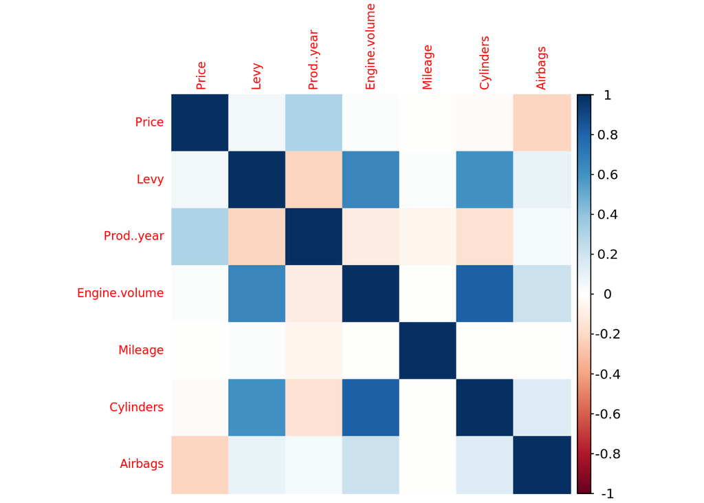

```r
corrplot(cor_matrix, method = "color", tl.cex = 0.7)
```

### Методы машинного обучения

Мы использовали модель случайного леса. Разделили данные из датасета на обучающую и тестовую (80% и 20%). Обучили модель случайного леса с 100 деревьями на основе всех признаков из датасета предсказывать целевую переменную Price и проверили точность на тестовой выборке. Решили повысить точность, таким же образом протестировали модель с 400 и 350 деревьями, затем провели кросс-валидацию для этих трех моделей и на основе RMSE и R^2 выявили, что модель с 350 деревьями - лучшая, в приложении использовали ее.

```r
# Разделим выборку на тестовую и обучающую
set.seed(123)
train_index <- createDataPartition(df_clean$Price, p = 0.8, list = FALSE)
train_data <- df_clean[train_index, ]
test_data <- df_clean[-train_index, ]

# Построим модель "случайного леса"
rf_model <- randomForest(Price ~ ., data = train_data, ntree = 100, importance = TRUE,   mtry = floor(sqrt(ncol(train_data) - 1)))
print(rf_model)
```

```
##
## Call:
##  randomForest(formula = Price ~ ., data = train_data, ntree = 100,      importance = TRUE, mtry = floor(sqrt(ncol(train_data) - 1)))
##                Type of random forest: regression
##                      Number of trees: 100
## No. of variables tried at each split: 4
##
##           Mean of squared residuals: 135660195
##                     % Var explained: 63.51
```

```r
preds <- predict(rf_model, newdata = test_data)

# Значения RMSE и R^2
actual <- test_data$Price
rmse <- sqrt(mean((preds - actual)^2))
r_squared <- 1 - sum((preds - actual)^2) / sum((actual - mean(actual))^2)
mae <- mean(abs(preds - actual))

cat("RMSE:", round(rmse, 2), "\n")
```

```
## RMSE: 9057.47
```

```r
cat("R-squared:", round(r_squared, 3), "\n")
```

```
## R-squared: 0.694
```

```r
cat("MAE:", round(mae, 3), "\n")
```

```
## MAE: 5897.375
```

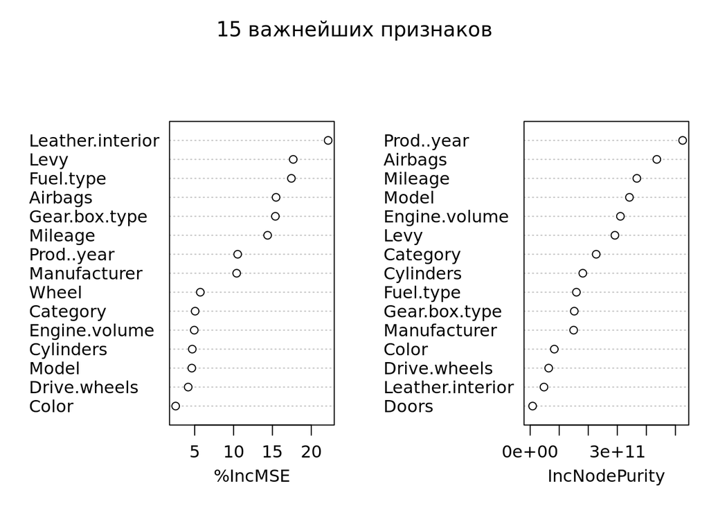

```r
# Посмотрим на важность признаков
varImpPlot(rf_model, n.var = 15, main = "15 важнейших признаков")
```

```r
#попробуем улучшить модель
# Улучшенная модель случайного леса с ручным подбором параметров
set.seed(123)

# Количество деревьев и количество признаков на каждом сплите
improved_rf <- randomForest(
  Price ~ .,
  data = train_data,
  ntree = 400,               # больше деревьев
  mtry = floor(sqrt(ncol(train_data) - 1)),  # корень из количества признаков
  importance = TRUE
)

# Предсказания
improved_preds <- predict(improved_rf, newdata = test_data)
actual <- test_data$Price

# Метрики
rmse_imp <- sqrt(mean((improved_preds - actual)^2))
mae_imp <- mean(abs(improved_preds - actual))
r2_imp <- 1 - sum((improved_preds - actual)^2) / sum((actual - mean(actual))^2)

# Вывод
cat("Улучшенная (упрощённая) модель Random Forest:\n")
```

```
## Улучшенная (упрощённая) модель Random Forest:
```

```r
cat("RMSE:", round(rmse_imp, 2), "\n")
```

```
## RMSE: 8945.79
```

```r
cat("MAE:", round(mae_imp, 2), "\n")
```

```
## MAE: 5837.14
```

```r
cat("R-squared:", round(r2_imp, 3), "\n")
```

```
## R-squared: 0.702
```

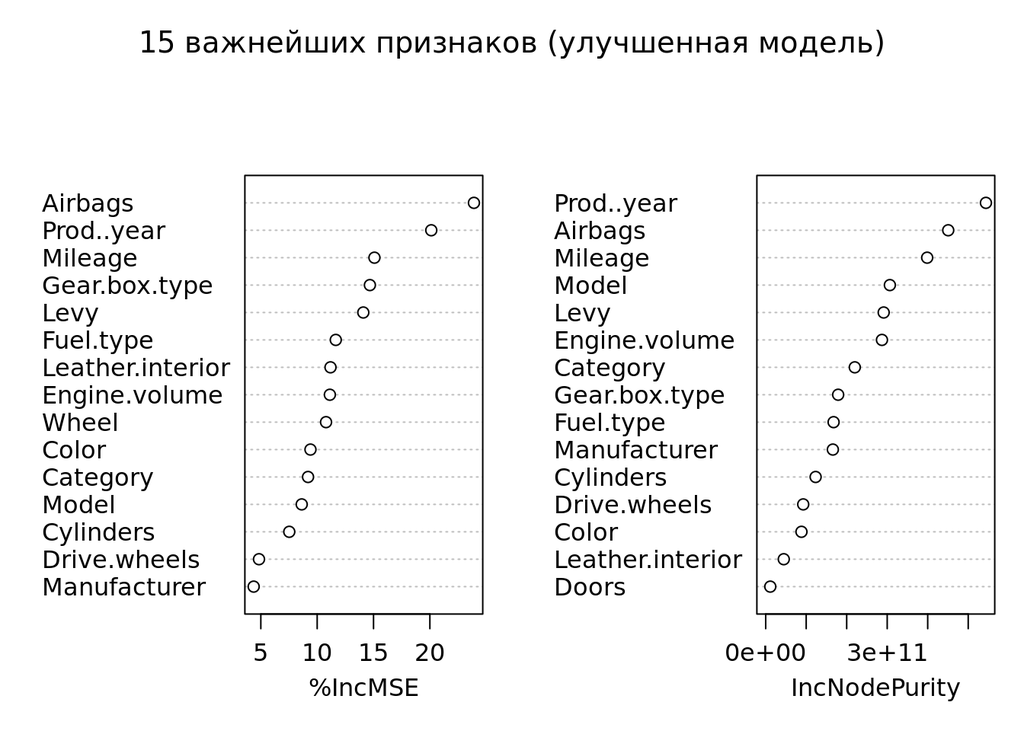

```r
# Важность переменных
varImpPlot(improved_rf, n.var = 15, main = "15 важнейших признаков (улучшенная модель)")
```

```r
# Построим модель "случайного леса"
rf_model <- randomForest(Price ~ ., data = train_data, ntree = 350, importance = TRUE,   mtry = floor(sqrt(ncol(train_data) - 1)))
print(rf_model)
```

```
##
## Call:
##  randomForest(formula = Price ~ ., data = train_data, ntree = 350,      importance = TRUE, mtry = floor(sqrt(ncol(train_data) - 1)))
##                Type of random forest: regression
##                      Number of trees: 350
## No. of variables tried at each split: 4
##
##           Mean of squared residuals: 129280618
##                     % Var explained: 65.22
```

```r
preds <- predict(rf_model, newdata = test_data)

# Значения RMSE и R^2
actual <- test_data$Price
rmse <- sqrt(mean((preds - actual)^2))
r_squared <- 1 - sum((preds - actual)^2) / sum((actual - mean(actual))^2)
mae <- mean(abs(preds - actual))

cat("RMSE:", round(rmse, 2), "\n")
```

```
## RMSE: 8901.44
```

```r
cat("R-squared:", round(r_squared, 3), "\n")
```

```
## R-squared: 0.705
```

```r
cat("MAE:", round(mae, 3), "\n")
```

```
## MAE: 5820.116
```

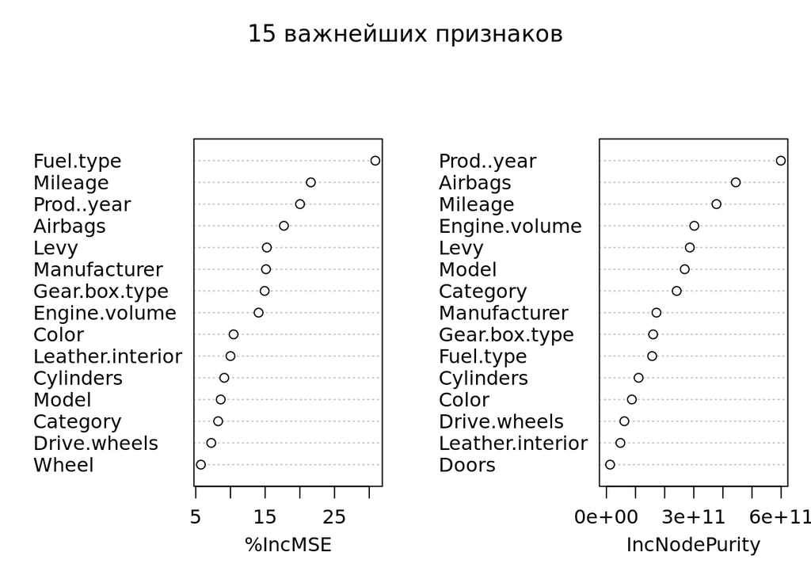

```r
# Посмотрим на важность признаков
varImpPlot(rf_model, n.var = 15, main = "15 важнейших признаков")
```

Выше мы описали построение модели Далее рассмотрим три модели для сравнения по параметрам и избрания подходящей:

```r
library(caret)
library(randomForest)

set.seed(123)

# Задаём контроль для 5-фолдовой кросс-валидации
control <- trainControl(method = "cv", number = 5)

# 1. Базовая модель (ntree = 100)
rf_base <- train(
  Price ~ ., data = df_clean,
  method = "rf",
  trControl = control,
  tuneGrid = data.frame(mtry = floor(sqrt(ncol(df_clean) - 1))),
  ntree = 100
)

# 2. Улучшенная модель (ntree = 400)
rf_400 <- train(
  Price ~ ., data = df_clean,
  method = "rf",
  trControl = control,
  tuneGrid = data.frame(mtry = floor(sqrt(ncol(df_clean) - 1))),
  ntree = 400
)

# 3. Финальная модель (ntree = 350)
rf_350 <- train(
  Price ~ ., data = df_clean,
  method = "rf",
  trControl = control,
  tuneGrid = data.frame(mtry = floor(sqrt(ncol(df_clean) - 1))),
  ntree = 350
)

# Сравнение результатов
rf_base
rf_400
rf_350
```

[output not shown]

### Архитектура приложения

В части с сервером загружаются библиотеки и заранее обученная нами модель случайного леса с 350 деревьями из файла .Rda. Приложение собирает информацию из введенных полей интерфейса и формирует из этой информации датасет с одним наблюдением. Далее с помощью загруженной обученной модели на этом наблюдении предсказывается цена для него. Для этой цены рассчитывается доверительный интервал на основе нормального распределения с заданным уровнем доверия, и выводится на экран сама цена, а также доверительный интервал. История запросов сохраняется, результаты не сохраняются.

### Интерфейс

В приложении построены поля для ввода значений, копка выбора упрощенного/расширенного режима. Добавлено название проекта “Предсказание рыночной стоимости автомобиля”. Добавлена панель для выбора режима с вариантами: “Упрощенный”, “Расширенный” - отвечает за то, какой режим интерфейса будет показан. Если упрощенный, то будут поля для марки (выпадающий список), модели (поле для ввода значения) и года выпуска автомобиля (поле для ввода значения, ограничение - минимум 1980, максимум 2025), поле для ввода уровня доверия доверительного интервала (поле для ввода значения, ограничение - минимум 50, максимум 99), а также кнопка “Рассчитать цену автомобиля”. Если режим выбран расширенный, то выводятся, помимо описанных, поля “Кожанный салон:” (кожаный или нет салон у автомобиля, выпадающий список с вариантами Yes/No), “Тип топлива:” (выпадающий список с вариантами “Petrol”, “Diesel”, “Hybrid”, “LPG”, “CNG”), “Пробег (км):” (поле для ввода значения, ограничение - минимум 0), “Объем двигателя (л):” (поле для ввода значения, ограничение - минимум 0.1), “Количество цилиндров:” (поле для ввода значения, ограничение - минимум 1), “Тип коробки передач:” (выпадающий список с вариантами ответа “Automatic”, “Tiptronic”, “Manual”, “Variator”). При нажатии на кнопку “Рассчитать цену автомобиля” на экран выводится сообщение “Оценочная стоимость (долларов США): X”, а также “Доверительный интервал (X%): X - X”. Также с помощью messagehandler добавлено сохранение истории запросов. Стоит отметить, что часть интерфейса собирается в разделе с сервером.

**Входные данные:** Режим: Упрощенный Марка машины: LEXUS Модель машины: LX570 Год выпуска: 2010 Уровень доверия 95%

**Выходные данные:** Оценочная стоимость (долларов США): 9165.51 Доверительный интервал (95%): 6225.56 - 12105.45

**Скрин интерфейса:**

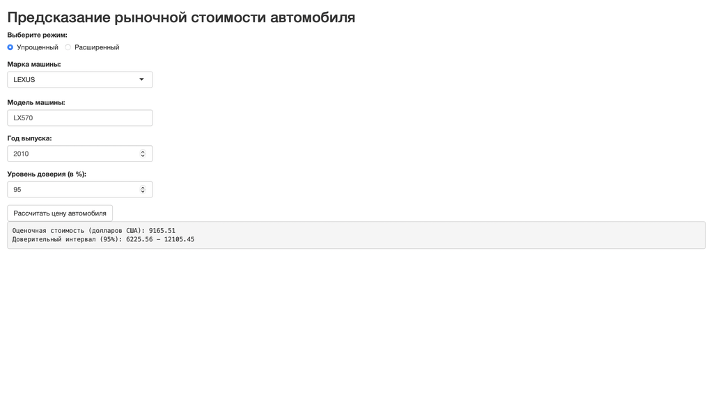

**Код интерфейса:**

```r
ui <- fluidPage(
  useShinyjs(),
  tags$script(HTML("
    Shiny.addCustomMessageHandler('saveInput', function(data) {
      localStorage.setItem(data.key, data.value);
    });

    Shiny.addCustomMessageHandler('loadInputs', function(keys) {
      keys.forEach(function(key) {
        var value = localStorage.getItem(key);
        if (value !== null) {
          Shiny.setInputValue(key, value);
        }
      });
    });
  ")),

  titlePanel("Предсказание рыночной стоимости автомобиля"),

  radioButtons("mode", "Выберите режим:", choices = c("Упрощенный", "Расширенный"), selected = "Упрощенный", inline = TRUE),

  uiOutput("input_fields"),

  numericInput("confidence", "Уровень доверия (в %):", value = 0, min = 50, max = 99),

  actionButton("predict_btn", "Рассчитать цену автомобиля"),

  br(),
  verbatimTextOutput("result")
)
```

**Код сервера:**

```r
library(shiny)
library(shinyjs)
library(corrplot)
library(dplyr)
library(caret)
library(randomForest)
library(ggplot2)



load(file = "model.Rda")

server <- function(input, output, session) {

  keys_to_store <- c("brand", "model", "year", "leather", "fuel", "mileage", "engine_size", "cylinders", "gearbox", "confidence")

  session$sendCustomMessage("loadInputs", keys_to_store)

  observe({
    for (key in keys_to_store) {
      val <- input[[key]]
      if (!is.null(val)) {
        session$sendCustomMessage("saveInput", list(key = key, value = as.character(val)))
      }
    }
  })

  output$input_fields <- renderUI({
    req(input$mode)

    common_fields <- tagList(
      selectInput("brand", "Марка машины:", choices = c('ACURA','ALFA ROMEO','ASTON MARTIN','AUDI','BENTLEY','BMW','BUICK','CADILLAC','CHEVROLET','CHRYSLER','CITROEN','DAEWOO',
                                                        'DAIHATSU',
                                                        'DODGE',
                                                        'FERRARI',
                                                        'FIAT',
                                                        'FORD',
                                                        'GAZ',
                                                        'GMC',
                                                        'GREATWALL',
                                                        'HAVAL',
                                                        'HONDA',
                                                        'HUMMER',
                                                        'HYUNDAI',
                                                        'INFINITI',
                                                        'ISUZU',
                                                        'JAGUAR',
                                                        'JEEP',
                                                        'KIA',
                                                        'LAMBORGHINI',
                                                        'LANCIA',
                                                        'LAND ROVER',
                                                        'LEXUS',
                                                        'LINCOLN',
                                                        'MASERATI',
                                                        'MAZDA',
                                                        'MERCEDES-BENZ',
                                                        'MERCURY',
                                                        'MINI',
                                                        'MITSUBISHI',
                                                        'MOSKVICH',
                                                        'NISSAN',
                                                        'OPEL',
                                                        'PEUGEOT',
                                                        'PONTIAC',
                                                        'PORSCHE',
                                                        'RENAULT',
                                                        'ROLLS-ROYCE',
                                                        'ROVER',
                                                        'SAAB',
                                                        'SATURN',
                                                        'SCION',
                                                        'SEAT',
                                                        'SKODA',
                                                        'SSANGYONG',
                                                        'SUBARU',
                                                        'SUZUKI',
                                                        'TESLA',
                                                        'TOYOTA',
                                                        'UAZ',
                                                        'VAZ',
                                                        'VOLKSWAGEN',
                                                        'VOLVO',
                                                        'ZAZ',
                                                        'სხვა')),
      textInput("model", "Модель машины:"),
      numericInput("year", "Год выпуска:", value = 2015, min = 1980, max = 2025)
    )

    extended_fields <- tagList(
      selectInput("leather", "Кожанный салон:", choices = c("Yes", "No")),
      selectInput("fuel", "Тип топлива:", choices = c("Petrol", "Diesel", "Hybrid", "LPG", "CNG")),
      numericInput("mileage", "Пробег (км):", value = 50000, min = 0),
      numericInput("engine_size", "Объем двигателя (л):", value = 2.0, min = 0.1),
      numericInput("cylinders", "Количество цилиндров:", value = 4, min = 1),
      selectInput("gearbox", "Тип коробки передач:", choices = c("Automatic", "Tiptronic", "Manual", "Variator"))
    )

    if (input$mode == "Упрощенный") {
      return(common_fields)
    } else {
      return(tagList(common_fields, extended_fields))
    }
  })

  prediction_text <- reactiveVal("")

  output$result <- renderText({
    prediction_text()
  })

  observeEvent(input$predict_btn, {
    tryCatch({
      validate(
        need(!is.null(input$brand) && input$brand != "", "Введите марку машины"),
        need(!is.null(input$model) && input$model != "", "Введите модель машины"),
        need(!is.na(input$year) && input$year >= 1980 && input$year <= 2025, "Год выпуска должен быть от 1980 до 2025")#,
        #need(!is.na(input$confidence) && input$confidence > 0 && input$confidence < 100, "Уровень доверия должен быть от 1 до 99")
      )

      if (input$mode == "Расширенный") {
        validate(
          need(!is.na(input$mileage), "Введите пробег"),
          need(!is.na(input$engine_size), "Введите объем двигателя"),
          need(!is.na(input$cylinders), "Введите количество цилиндров"),
          need(!is.null(input$fuel), "Выберите тип топлива"),
          need(!is.null(input$leather), "Выберите кожанный салон"),
          need(!is.null(input$gearbox), "Выберите тип коробки передач")
        )
      }

      car_data <- list(
        Manufacturer = input$brand,
        Model = input$model,
        Prod..year = input$year,
        Leather.interior = ifelse(input$mode == "Расширенный", input$leather, 'Yes'),
        Fuel.type = ifelse(input$mode == "Расширенный", input$fuel, 'Petrol'),
        Engine.volume = ifelse(input$mode == "Расширенный", input$engine_size, 2.0),
        Mileage = ifelse(input$mode == "Расширенный", input$mileage, 50000),
        Cylinders = ifelse(input$mode == "Расширенный", input$cylinders, 4),
        Gear.box.type = ifelse(input$mode == "Расширенный", input$gearbox, 'Automatic')
      )

      prediction <- predict(rf_350, newdata = as.data.frame(car_data))

      conf_level <- input$confidence / 100
      z <- qnorm(1 - (1 - conf_level)/2)
      std_error <- 1500

      lower <- prediction - z * std_error
      upper <- prediction + z * std_error

      prediction_text(
        paste0("Оценочная стоимость (долларов США): ", round(prediction, 2),
               "\nДоверительный интервал (", input$confidence, "%): ",
               round(lower, 2), " - ", round(upper, 2))
      )
    },
    error = function(e) {
      showNotification(paste("Ошибка:", e$message), type = "error")
    })
  })
}

shinyApp(ui, server)
```